# Assignment 1

Rex Shen

9/23/2021

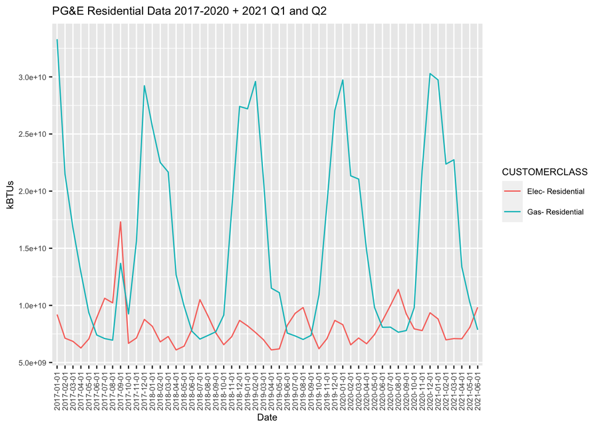

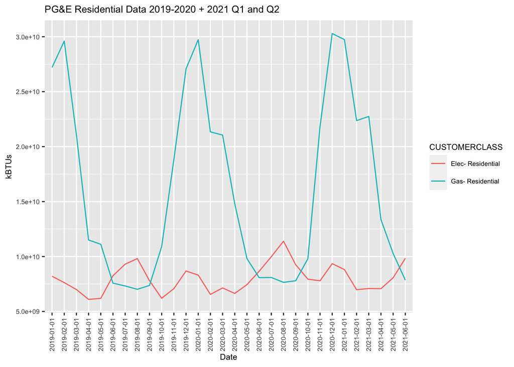

In the PG&E Residential Data for $2017$ to $2020$ and $2021 \, Q1$ and $Q2$, we observe an outlier for September $2017$ in that the total kBTUs for the Elec Residential is significantly higher than that of the other months in the time series for the Elec Residential. Perhaps, there was some sort of issue with how the total kBTUs were collected for that particular month. Now, we take a look at $2017$ in more detail.

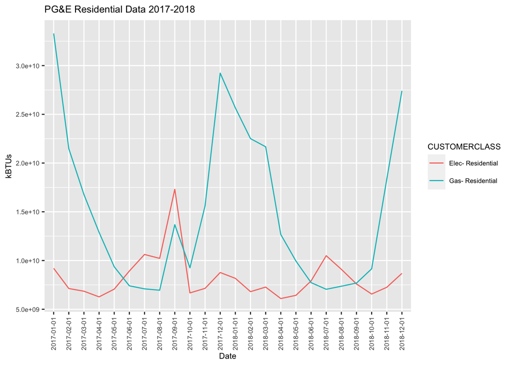

[output not shown]

[output cut: 1549 more lines]

If we take a look at this “Gorilla Problem,” we see that the outlier can be partially attributed to whether or not the Zip Codes were combined or not with other Zip Codes. Perhaps, this may have caused double counting, and, ultimately, higher totals of kBTUs.

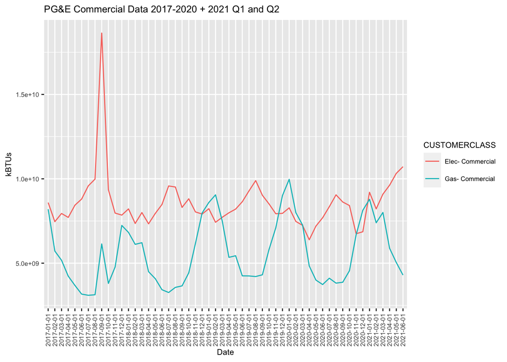

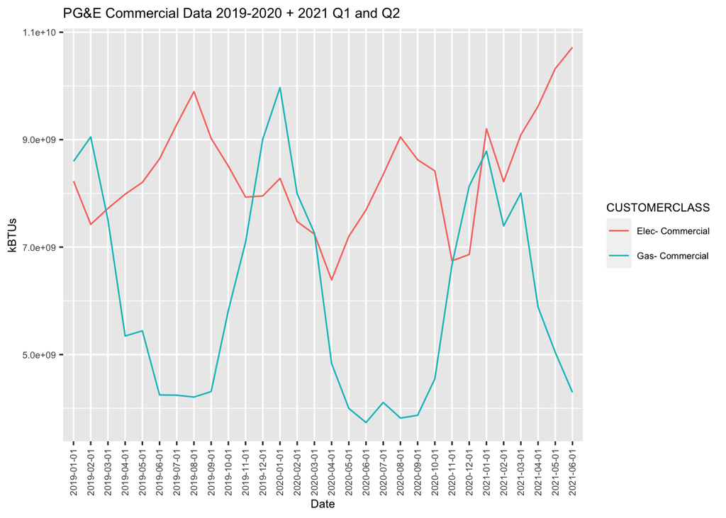

### Summarizing Results & COVID Pandemic Analysis

In terms of the key assumptions made in the analysis and/or caveats we should be aware of, note that the website https://pge-energydatarequest.com/ states that the data contains “a minimum of 100 Residential Customers, a minimum of 15 Non-Residential Customers, with no single Non-Residential Customer in each sector accounting for more than $15\%$ of the total consumption. If the aggregation standard is not met, the consumption will be combined with a neighboring ZIP code until the aggregation requirements are met.” Thus, it assumes that the if the aggregation standard is not met, the consumption combined with the neighboring ZIP code will have a negligible impact on drawing conclusions from the data. Moreover, we also assume that the data is well-representative of the population, and that the information is accurate, as the KWhs and Therms are accurately measured.